# Project 1: Investigating GAPMINDER WORLD

- Introduction
- Data Wrangling
- Exploratory Data Analysis
- Conclusions

## Introduction

The selected data is from the Gapminder world and 5 different indicators were selected for the analysis, namely: population_total, income_per_person_gdppercapita_ppp_inflation_adjusted, life_expectancy_years, children_per_woman_total_fertility and child_mortality_0_5_year_olds_dying_per_1000_born. In this project I am going to use population as a primary dependent variable and life expectancy as a secondary dependent variable. There are 64113 observations and 7 features to start with and for further analysis, will be subset using 2 criterias:

1. Two dataset will be explored and compared, i.e. the country with the maximum recorded total population and the country with the lowest recorded population.
2. The above selected dataset will also be filtered for data recorded from 1950 and onwards.

### Question(s) for Analysis

Q1. Besides the significant population difference between India and Brunei, what other trends in terms of fluctuations are observed over the given time period 1800 to 2050?

Q2. What are the notable differences and similarities between India and Brunei, with regards to life expectancy, children per woman, child mortality from 1950 going onwards?

Q3. Which factors significatly contribute to the increase in population for Brunei and India from 1950 going forward?

Q4. Which country has the highest average life expectancy and by how much does its life expectancy contribute to the total population?

Q5. Which notable trends are common to both countries?

Q6. Is there relationship between children_per_woman_total_fertility and child_mortality_0_5_year_olds_dying_per_1000_born and how do they both affect or contribute to the total population life expectancy years in Brunei?

###### Importing the needed libraries

```python
import pandas as pd
import seaborn as sns
import matplotlib.pyplot as plt
import plotly.express as px
import numpy as np
import plotly.graph_objects as go
from plotly.subplots import make_subplots
from functools import reduce
%matplotlib inline
import warnings
warnings.filterwarnings("ignore")
warnings.simplefilter(action = "ignore", category = FutureWarning)
```

## Data Wrangling

###### Loading dataset

```python
# LOADING DATASET
income_df = pd.read_csv('income_per_person_gdppercapita_ppp_inflation_adjusted.csv')
life_expectancy_df = pd.read_csv('life_expectancy_years.csv')
population_df = pd.read_csv('population_total.csv')
child_mortality_df = pd.read_csv('child_mortality_0_5_year_olds_dying_per_1000_born.csv')
children_per_woman_df = pd.read_csv('children_per_woman_total_fertility.csv')
```

```python
income_df.head()
```

|  | country | 1800 | 1801 | 1802 | 1803 | 1804 | 1805 | 1806 | 1807 | 1808 | ... | 2041 | 2042 | 2043 | 2044 | 2045 | 2046 | 2047 | 2048 | 2049 | 2050 |
| --- | --- | --- | --- | --- | --- | --- | --- | --- | --- | --- | --- | --- | --- | --- | --- | --- | --- | --- | --- | --- | --- |
| 0 | Afghanistan | 683 | 683 | 683 | 683 | 683 | 683 | 683 | 683 | 683 | ... | 2690 | 2750 | 2810 | 2870 | 2930 | 2990 | 3060 | 3120 | 3190 | 3260 |
| 1 | Angola | 700 | 702 | 705 | 709 | 711 | 714 | 718 | 721 | 725 | ... | 8000 | 8170 | 8350 | 8530 | 8710 | 8900 | 9090 | 9280 | 9480 | 9690 |
| 2 | Albania | 755 | 755 | 755 | 755 | 755 | 756 | 756 | 756 | 756 | ... | 25.1k | 25.6k | 26.2k | 26.7k | 27.3k | 27.9k | 28.5k | 29.1k | 29.7k | 30.4k |
| 3 | Andorra | 1360 | 1360 | 1360 | 1360 | 1370 | 1370 | 1370 | 1370 | 1380 | ... | 68.9k | 70.4k | 71.9k | 73.4k | 75k | 76.6k | 78.3k | 80k | 81.7k | 83.4k |
| 4 | United Arab Emirates | 1130 | 1130 | 1140 | 1140 | 1150 | 1150 | 1160 | 1160 | 1160 | ... | 101k | 103k | 105k | 107k | 110k | 112k | 114k | 117k | 119k | 122k |

5 rows × 252 columns

```python
life_expectancy_df.head()
```

|  | country | 1800 | 1801 | 1802 | 1803 | 1804 | 1805 | 1806 | 1807 | 1808 | ... | 2091 | 2092 | 2093 | 2094 | 2095 | 2096 | 2097 | 2098 | 2099 | 2100 |
| --- | --- | --- | --- | --- | --- | --- | --- | --- | --- | --- | --- | --- | --- | --- | --- | --- | --- | --- | --- | --- | --- |
| 0 | Afghanistan | 28.2 | 28.2 | 28.2 | 28.2 | 28.2 | 28.2 | 28.1 | 28.1 | 28.1 | ... | 75.5 | 75.7 | 75.8 | 76.0 | 76.1 | 76.2 | 76.4 | 76.5 | 76.6 | 76.8 |
| 1 | Angola | 27.0 | 27.0 | 27.0 | 27.0 | 27.0 | 27.0 | 27.0 | 27.0 | 27.0 | ... | 78.8 | 79.0 | 79.1 | 79.2 | 79.3 | 79.5 | 79.6 | 79.7 | 79.9 | 80.0 |
| 2 | Albania | 35.4 | 35.4 | 35.4 | 35.4 | 35.4 | 35.4 | 35.4 | 35.4 | 35.4 | ... | 87.4 | 87.5 | 87.6 | 87.7 | 87.8 | 87.9 | 88.0 | 88.2 | 88.3 | 88.4 |
| 3 | Andorra | NaN | NaN | NaN | NaN | NaN | NaN | NaN | NaN | NaN | ... | NaN | NaN | NaN | NaN | NaN | NaN | NaN | NaN | NaN | NaN |
| 4 | United Arab Emirates | 30.7 | 30.7 | 30.7 | 30.7 | 30.7 | 30.7 | 30.7 | 30.7 | 30.7 | ... | 82.4 | 82.5 | 82.6 | 82.7 | 82.8 | 82.9 | 83.0 | 83.1 | 83.2 | 83.3 |

5 rows × 302 columns

```python
child_mortality_df.head()
```

|  | country | 1800 | 1801 | 1802 | 1803 | 1804 | 1805 | 1806 | 1807 | 1808 | ... | 2091 | 2092 | 2093 | 2094 | 2095 | 2096 | 2097 | 2098 | 2099 | 2100 |
| --- | --- | --- | --- | --- | --- | --- | --- | --- | --- | --- | --- | --- | --- | --- | --- | --- | --- | --- | --- | --- | --- |
| 0 | Afghanistan | 469.0 | 469.0 | 469.0 | 469.0 | 469.0 | 469.0 | 470.0 | 470.0 | 470.0 | ... | 12.60 | 12.40 | 12.20 | 12.00 | 11.80 | 11.60 | 11.50 | 11.30 | 11.10 | 11.10 |
| 1 | Angola | 486.0 | 486.0 | 486.0 | 486.0 | 486.0 | 486.0 | 486.0 | 486.0 | 486.0 | ... | 17.70 | 17.50 | 17.30 | 17.10 | 17.00 | 16.80 | 16.60 | 16.40 | 16.30 | 16.30 |
| 2 | Albania | 375.0 | 375.0 | 375.0 | 375.0 | 375.0 | 375.0 | 375.0 | 375.0 | 375.0 | ... | 2.32 | 2.30 | 2.27 | 2.24 | 2.22 | 2.19 | 2.16 | 2.14 | 2.11 | 2.11 |
| 3 | Andorra | NaN | NaN | NaN | NaN | NaN | NaN | NaN | NaN | NaN | ... | 0.86 | 0.84 | 0.83 | 0.81 | 0.80 | 0.79 | 0.78 | 0.77 | 0.76 | 0.76 |
| 4 | United Arab Emirates | 434.0 | 434.0 | 434.0 | 434.0 | 434.0 | 434.0 | 434.0 | 434.0 | 434.0 | ... | 2.31 | 2.29 | 2.26 | 2.24 | 2.22 | 2.19 | 2.17 | 2.15 | 2.13 | 2.13 |

5 rows × 302 columns

```python
children_per_woman_df.head()
```

|  | country | 1800 | 1801 | 1802 | 1803 | 1804 | 1805 | 1806 | 1807 | 1808 | ... | 2091 | 2092 | 2093 | 2094 | 2095 | 2096 | 2097 | 2098 | 2099 | 2100 |
| --- | --- | --- | --- | --- | --- | --- | --- | --- | --- | --- | --- | --- | --- | --- | --- | --- | --- | --- | --- | --- | --- |
| 0 | Aruba | 5.64 | 5.64 | 5.64 | 5.64 | 5.64 | 5.64 | 5.64 | 5.64 | 5.64 | ... | 1.82 | 1.82 | 1.82 | 1.82 | 1.82 | 1.82 | 1.82 | 1.82 | 1.83 | 1.83 |
| 1 | Afghanistan | 7.00 | 7.00 | 7.00 | 7.00 | 7.00 | 7.00 | 7.00 | 7.00 | 7.00 | ... | 1.74 | 1.74 | 1.74 | 1.74 | 1.74 | 1.74 | 1.74 | 1.74 | 1.74 | 1.74 |
| 2 | Angola | 6.93 | 6.93 | 6.93 | 6.93 | 6.93 | 6.93 | 6.93 | 6.94 | 6.94 | ... | 2.54 | 2.52 | 2.50 | 2.48 | 2.47 | 2.45 | 2.43 | 2.42 | 2.40 | 2.40 |
| 3 | Albania | 4.60 | 4.60 | 4.60 | 4.60 | 4.60 | 4.60 | 4.60 | 4.60 | 4.60 | ... | 1.78 | 1.78 | 1.78 | 1.79 | 1.79 | 1.79 | 1.79 | 1.79 | 1.79 | 1.79 |
| 4 | Netherlands Antilles | 5.80 | 5.80 | 5.80 | 5.80 | 5.80 | 5.80 | 5.80 | 5.80 | 5.80 | ... | 2.00 | 2.00 | 2.01 | 2.01 | 2.01 | 2.01 | 2.01 | 2.02 | 2.02 | 2.02 |

5 rows × 302 columns

```python
population_df.head()
```

|  | country | 1800 | 1801 | 1802 | 1803 | 1804 | 1805 | 1806 | 1807 | 1808 | ... | 2091 | 2092 | 2093 | 2094 | 2095 | 2096 | 2097 | 2098 | 2099 | 2100 |
| --- | --- | --- | --- | --- | --- | --- | --- | --- | --- | --- | --- | --- | --- | --- | --- | --- | --- | --- | --- | --- | --- |
| 0 | Afghanistan | 3.28M | 3.28M | 3.28M | 3.28M | 3.28M | 3.28M | 3.28M | 3.28M | 3.28M | ... | 76.6M | 76.4M | 76.3M | 76.1M | 76M | 75.8M | 75.6M | 75.4M | 75.2M | 74.9M |
| 1 | Angola | 1.57M | 1.57M | 1.57M | 1.57M | 1.57M | 1.57M | 1.57M | 1.57M | 1.57M | ... | 168M | 170M | 172M | 175M | 177M | 179M | 182M | 184M | 186M | 188M |
| 2 | Albania | 400k | 402k | 404k | 405k | 407k | 409k | 411k | 413k | 414k | ... | 1.33M | 1.3M | 1.27M | 1.25M | 1.22M | 1.19M | 1.17M | 1.14M | 1.11M | 1.09M |
| 3 | Andorra | 2650 | 2650 | 2650 | 2650 | 2650 | 2650 | 2650 | 2650 | 2650 | ... | 63k | 62.9k | 62.9k | 62.8k | 62.7k | 62.7k | 62.6k | 62.5k | 62.5k | 62.4k |
| 4 | United Arab Emirates | 40.2k | 40.2k | 40.2k | 40.2k | 40.2k | 40.2k | 40.2k | 40.2k | 40.2k | ... | 12.3M | 12.4M | 12.5M | 12.5M | 12.6M | 12.7M | 12.7M | 12.8M | 12.8M | 12.9M |

5 rows × 302 columns

###### Re-structuring of the dataset - melting

Changing the dataframe from wide to long so as to better unders the nature of the dataset

```python
income_df = income_df.melt(id_vars =['country'], var_name='year', value_name='income')
income_df.head()
```

|  | country | year | income |
| --- | --- | --- | --- |
| 0 | Afghanistan | 1800 | 683 |
| 1 | Angola | 1800 | 700 |
| 2 | Albania | 1800 | 755 |
| 3 | Andorra | 1800 | 1360 |
| 4 | United Arab Emirates | 1800 | 1130 |

```python
life_expectancy_df = life_expectancy_df.melt(id_vars =['country'], var_name='year', value_name='life_expectancy')
life_expectancy_df.head()
```

|  | country | year | life_expectancy |
| --- | --- | --- | --- |
| 0 | Afghanistan | 1800 | 28.2 |
| 1 | Angola | 1800 | 27.0 |
| 2 | Albania | 1800 | 35.4 |
| 3 | Andorra | 1800 | NaN |
| 4 | United Arab Emirates | 1800 | 30.7 |

```python
child_mortality_df = child_mortality_df.melt(id_vars =['country'], var_name='year', value_name='child_mortality')
child_mortality_df.head()
```

|  | country | year | child_mortality |
| --- | --- | --- | --- |
| 0 | Afghanistan | 1800 | 469.0 |
| 1 | Angola | 1800 | 486.0 |
| 2 | Albania | 1800 | 375.0 |
| 3 | Andorra | 1800 | NaN |
| 4 | United Arab Emirates | 1800 | 434.0 |

```python
children_per_woman_df = children_per_woman_df.melt(id_vars =['country'], var_name='year', value_name='children_per_woman')
children_per_woman_df.head()
```

|  | country | year | children_per_woman |
| --- | --- | --- | --- |
| 0 | Aruba | 1800 | 5.64 |
| 1 | Afghanistan | 1800 | 7.00 |
| 2 | Angola | 1800 | 6.93 |
| 3 | Albania | 1800 | 4.60 |
| 4 | Netherlands Antilles | 1800 | 5.80 |

```python
population_df = population_df.melt(id_vars =['country'], var_name='year', value_name='population')
population_df.head()
```

|  | country | year | population |
| --- | --- | --- | --- |
| 0 | Afghanistan | 1800 | 3.28M |
| 1 | Angola | 1800 | 1.57M |
| 2 | Albania | 1800 | 400k |
| 3 | Andorra | 1800 | 2650 |
| 4 | United Arab Emirates | 1800 | 40.2k |

#### Merging the dataframes

For ease of manipulating and analysing data

```python
# list of DataFrames
data_df =  [income_df, population_df, life_expectancy_df, child_mortality_df, children_per_woman_df,]

#merging all DataFrames into one
final_df = reduce(lambda  left,right: pd.merge(left, right, on=["country", "year"], how='outer'), data_df)
final_df.head()
```

|  | country | year | income | population | life_expectancy | child_mortality | children_per_woman |
| --- | --- | --- | --- | --- | --- | --- | --- |
| 0 | Afghanistan | 1800 | 683 | 3.28M | 28.2 | 469.0 | 7.00 |
| 1 | Angola | 1800 | 700 | 1.57M | 27.0 | 486.0 | 6.93 |
| 2 | Albania | 1800 | 755 | 400k | 35.4 | 375.0 | 4.60 |
| 3 | Andorra | 1800 | 1360 | 2650 | NaN | NaN | NaN |
| 4 | United Arab Emirates | 1800 | 1130 | 40.2k | 30.7 | 434.0 | 6.94 |

```python
final_df.info() #Column names, datatypes, column labels
final_df.shape #number of columns and rows
```

```
<class 'pandas.core.frame.DataFrame'>
Int64Index: 64113 entries, 0 to 64112
Data columns (total 7 columns):
 #   Column              Non-Null Count  Dtype
---  ------              --------------  -----
 0   country             64113 non-null  object
 1   year                64113 non-null  object
 2   income              48945 non-null  object
 3   population          59297 non-null  object
 4   life_expectancy     56616 non-null  float64
 5   child_mortality     57497 non-null  float64
 6   children_per_woman  60715 non-null  float64
dtypes: float64(3), object(4)
memory usage: 3.9+ MB
```

```
(64113, 7)
```

##### Null values

```python
final_df.isnull().sum()/len(final_df) # proportion of columns with missing values
```

```
country               0.000000
year                  0.000000
income                0.236582
population            0.075117
life_expectancy       0.116934
child_mortality       0.103193
children_per_woman    0.053000
dtype: float64
```

##### Datatypes

```python
final_df.dtypes
```

```
country                object
year                   object
income                 object
population             object
life_expectancy       float64
child_mortality       float64
children_per_woman    float64
dtype: object
```

## Data Cleaning

```python
final_df.dropna(inplace = True) #drop rows with NaN values
```

```python
final_df.info()
print(final_df.shape)
```

```
<class 'pandas.core.frame.DataFrame'>
Int64Index: 46536 entries, 0 to 48944
Data columns (total 7 columns):
 #   Column              Non-Null Count  Dtype
---  ------              --------------  -----
 0   country             46536 non-null  object
 1   year                46536 non-null  object
 2   income              46536 non-null  object
 3   population          46536 non-null  object
 4   life_expectancy     46536 non-null  float64
 5   child_mortality     46536 non-null  float64
 6   children_per_woman  46536 non-null  float64
dtypes: float64(3), object(4)
memory usage: 2.8+ MB
(46536, 7)
```

##### Datatype conversion

```python
#converting string to int
final_df['population'] = final_df['population'].replace({'B': '*1e9', 'k':'*1e3', 'M': '*1e6', '-':'-1'}, regex =True).map(pd.eval).astype(int)
final_df['population'].head()
```

```
0    3280000
1    1570000
2     400000
4      40200
5     534000
Name: population, dtype: int32
```

```python
#converting string to int
final_df['income'] = final_df['income'].replace({'B': '*1e9', 'k': '*1e3', 'M': '*1e6', '-':'-1'}, regex =True).map(pd.eval).astype(float)
final_df['income'].head()
```

```
0     683.0
1     700.0
2     755.0
4    1130.0
5    1730.0
Name: income, dtype: float64
```

```python
#converting string to int
final_df['year'] = final_df['year'].astype(int)
final_df['year'].head()
```

```
0    1800
1    1800
2    1800
4    1800
5    1800
Name: year, dtype: int32
```

```python
final_df.info()
```

```
<class 'pandas.core.frame.DataFrame'>
Int64Index: 46536 entries, 0 to 48944
Data columns (total 7 columns):
 #   Column              Non-Null Count  Dtype
---  ------              --------------  -----
 0   country             46536 non-null  object
 1   year                46536 non-null  int32
 2   income              46536 non-null  float64
 3   population          46536 non-null  int32
 4   life_expectancy     46536 non-null  float64
 5   child_mortality     46536 non-null  float64
 6   children_per_woman  46536 non-null  float64
dtypes: float64(4), int32(2), object(1)
memory usage: 2.5+ MB
```

The data is now ready to be analysed

```python
final_df.shape #number of rows and columns
```

```
(46536, 7)
```

## Exploratory Data Analysis

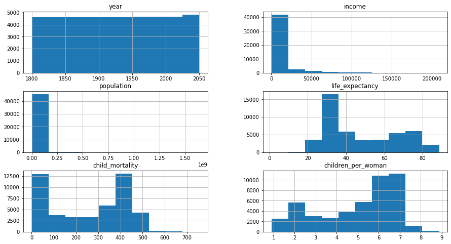

```python
final_df.hist(figsize=(15,8));
```

From the above histograms, the following were noted: 1.population - right skewed 2.income - right skewed

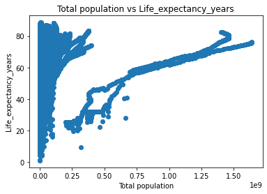

```python
# Relationship between population and life expectancy in the entire dataset
plt.scatter(final_df['population'], final_df['life_expectancy'])
plt.xlabel('Total population')
plt.ylabel('Life_expectancy_years')
plt.title('Total population vs Life_expectancy_years');
```

In this project I am going to use population as a primary dependent variable and life expectancy as a secondary dependent variable. Two dataset will be explored and compared, i.e. the country with the maximum recorded total population and the country with the lowest recorded population.

```python
#Filtering the country that has recorded the highest recorded total population
Highest_population = final_df.groupby('country')['population'].max().sort_values(ascending = False)
Highest_population.head(1)
```

```
country
India    1640000000
Name: population, dtype: int32
```

```python
# subsetting final_df to have data from India
df_india = final_df[final_df['country'] == 'India']
df_india.head()
```

|  | country | year | income | population | life_expectancy | child_mortality | children_per_woman |
| --- | --- | --- | --- | --- | --- | --- | --- |
| 78 | India | 1800 | 1200.0 | 201000000 | 25.4 | 509.0 | 5.95 |
| 273 | India | 1801 | 1200.0 | 201000000 | 25.4 | 509.0 | 5.95 |
| 468 | India | 1802 | 1200.0 | 202000000 | 25.0 | 509.0 | 5.95 |
| 663 | India | 1803 | 1190.0 | 202000000 | 24.0 | 509.0 | 5.95 |
| 858 | India | 1804 | 1180.0 | 202000000 | 23.5 | 509.0 | 5.95 |

```python
df_india.describe() # DESCRIPTION OF THE DATA IN THE DATAFRAME
```

|  | year | income | population | life_expectancy | child_mortality | children_per_woman |
| --- | --- | --- | --- | --- | --- | --- |
| count | 251.000000 | 251.000000 | 2.510000e+02 | 251.000000 | 251.000000 | 251.000000 |
| mean | 1925.000000 | 2849.262948 | 5.791315e+08 | 41.131912 | 314.945020 | 4.979124 |
| std | 72.601653 | 3846.613456 | 4.645119e+08 | 18.766823 | 190.480559 | 1.470516 |
| min | 1800.000000 | 980.000000 | 2.010000e+08 | 9.310000 | 14.700000 | 1.840000 |
| 25% | 1862.500000 | 1100.000000 | 2.475000e+08 | 25.400000 | 136.000000 | 4.265000 |
| 50% | 1925.000000 | 1250.000000 | 3.310000e+08 | 31.200000 | 294.000000 | 5.800000 |
| 75% | 1987.500000 | 1665.000000 | 8.285000e+08 | 58.450000 | 509.000000 | 5.950000 |
| max | 2050.000000 | 17500.000000 | 1.640000e+09 | 76.200000 | 537.000000 | 5.950000 |

```python
#filtering the country that has recorded the lowest recorded total population
Lowest_population = final_df.groupby('country')['population'].min().sort_values(ascending = False)
Lowest_population.tail(1)
```

```
country
Brunei    2260
Name: population, dtype: int32
```

```python
# subsetting final_df to have data from Brunei
df_brunei = final_df[final_df['country'] == 'Brunei']
df_brunei.head()
```

|  | country | year | income | population | life_expectancy | child_mortality | children_per_woman |
| --- | --- | --- | --- | --- | --- | --- | --- |
| 25 | Brunei | 1800 | 1710.0 | 2260 | 29.2 | 455.0 | 7.06 |
| 220 | Brunei | 1801 | 1710.0 | 2260 | 29.2 | 455.0 | 7.06 |
| 415 | Brunei | 1802 | 1710.0 | 2260 | 29.2 | 455.0 | 7.06 |
| 610 | Brunei | 1803 | 1710.0 | 2260 | 29.2 | 455.0 | 7.06 |
| 805 | Brunei | 1804 | 1710.0 | 2260 | 29.2 | 455.0 | 7.06 |

```python
df_brunei.describe() # DESCRIPTION OF THE DATA IN THE DATAFRAME
```

|  | year | income | population | life_expectancy | child_mortality | children_per_woman |
| --- | --- | --- | --- | --- | --- | --- |
| count | 251.000000 | 251.000000 | 251.000000 | 251.000000 | 251.000000 | 251.000000 |
| mean | 1925.000000 | 34977.689243 | 131190.557769 | 46.929482 | 258.104064 | 5.605339 |
| std | 72.601653 | 39604.448329 | 173404.968099 | 19.732351 | 199.091251 | 2.187251 |
| min | 1800.000000 | 1710.000000 | 2260.000000 | 26.300000 | 6.410000 | 1.710000 |
| 25% | 1862.500000 | 1985.000000 | 5485.000000 | 29.200000 | 13.850000 | 3.695000 |
| 50% | 1925.000000 | 2470.000000 | 28900.000000 | 36.700000 | 316.000000 | 7.060000 |
| 75% | 1987.500000 | 71200.000000 | 241000.000000 | 69.050000 | 455.000000 | 7.060000 |
| max | 2050.000000 | 142000.000000 | 493000.000000 | 78.400000 | 455.000000 | 7.520000 |

#### Differences between the two countries

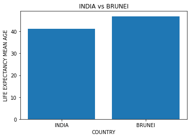

```python
plt.bar(['INDIA', 'BRUNEI'], [df_india.life_expectancy.mean(), df_brunei.life_expectancy.mean()])
plt.ylabel('LIFE EXPECTANCY MEAN AGE')
plt.xlabel('COUNTRY')
plt.title('INDIA vs BRUNEI');
```

LIFE EXPECTANCY MEAN AGE : INDIA vs BRUNEI

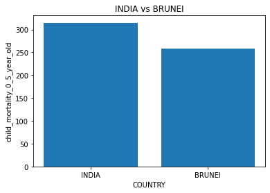

```python
plt.bar(['INDIA', 'BRUNEI'], [df_india.child_mortality.mean(), df_brunei.child_mortality.mean()])
plt.ylabel('child_mortality_0_5_year_old')
plt.xlabel('COUNTRY')
plt.title('INDIA vs BRUNEI');
```

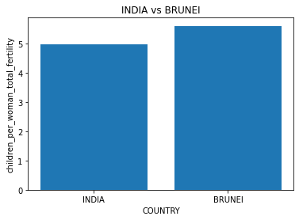

```python
plt.bar(['INDIA', 'BRUNEI'], [df_india.children_per_woman.mean(), df_brunei.children_per_woman.mean()])
plt.ylabel('children_per_woman_total_fertility')
plt.xlabel('COUNTRY')
plt.title('INDIA vs BRUNEI');
```

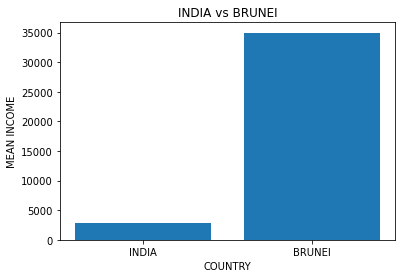

```python
plt.bar(['INDIA', 'BRUNEI'], [df_india.income.mean(), df_brunei.income.mean()])
plt.ylabel('MEAN INCOME')
plt.xlabel('COUNTRY')
plt.title('INDIA vs BRUNEI');
```

[figure not shown]

```python
plt.bar(['INDIA', 'BRUNEI'], [df_india.population.mean(), df_brunei.population.mean()])
plt.ylabel('LIFE EXPECTANCY MEAN AGE')
plt.xlabel('COUNTRY')
plt.title('INDIA vs BRUNEI');
```

#### Relationship between population and life expectancy? other factors considered as well

[figure not shown]

```python
plt.subplot
plt.scatter(df_brunei['population'],df_brunei['life_expectancy'])
plt.scatter(df_india['population'],df_india['life_expectancy'], color = 'r')
plt.xlabel('Total population')
plt.ylabel('Life_expectancy_years')
plt.title('Total population vs Life_expectancy_years')
plt.legend(['India', 'Brunei'], loc = 'lower right', title = 'Coutries');
```

[figure not shown]

```python
plt.subplot
plt.scatter(df_brunei['population'],df_brunei['income'])
plt.scatter(df_india['population'],df_india['income'], color = 'r')
plt.xlabel('Total population')
plt.ylabel('Income_per_person_gdp')
plt.title('Total population vs income_per_person')
plt.legend(['India', 'Brunei'], loc = 'best', title = 'Coutries' );
```

[figure not shown]

```python
plt.subplot
plt.scatter(df_brunei['population'],df_brunei['child_mortality'])
plt.scatter(df_india['population'],df_india['child_mortality'], color = 'r')
plt.xlabel('Total population')
plt.ylabel('Child_mortality_0_5_year')
plt.title('Total population vs child_mortality_0_5_year')
plt.legend(['India', 'Brunei'], loc = 'best', title = 'Coutries');
```

[figure not shown]

```python
plt.subplot
plt.scatter(df_brunei['population'],df_brunei['children_per_woman'])
plt.scatter(df_india['population'],df_india['children_per_woman'], color = 'r')
plt.xlabel('Total population')
plt.ylabel('Children_per_woman_total_fertility')
plt.title('Total population vs Children_per_woman_total_fertility')
plt.legend(['India', 'Brunei'], loc = 'best', title = 'Coutries');
```

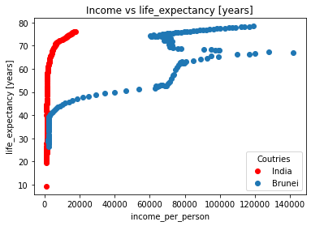

```python
plt.subplot
plt.scatter(df_india['income'],df_india['life_expectancy'], color = 'r')
plt.scatter(df_brunei['income'],df_brunei['life_expectancy'])
plt.xlabel('income_per_person')
plt.ylabel('life_expectancy [years]')
plt.title('Income vs life_expectancy [years]')
plt.legend(['India', 'Brunei'], loc = 'best', title = 'Coutries');
```

[figure not shown]

```python
plt.subplot
plt.scatter(df_india['child_mortality'],df_india['life_expectancy'], color = 'r')
plt.scatter(df_brunei['child_mortality'],df_brunei['life_expectancy'])
plt.xlabel('Child_mortality_0_5_year_olds')
plt.ylabel('Life_expectancy [years]')
plt.title('Income vs life_expectancy [years]')
plt.legend(['India', 'Brunei'], loc = 'best', title = 'Coutries');
```

[figure not shown]

```python
plt.subplot
plt.scatter(df_india['children_per_woman'],df_india['life_expectancy'], color = 'r')
plt.scatter(df_brunei['children_per_woman'],df_brunei['life_expectancy'])
plt.xlabel('children_per_woman_total_fertility')
plt.ylabel('life_expectancy [years]')
plt.title('Income vs life_expectancy [years]')
plt.legend(['India', 'Brunei'], loc = 'best', title = 'Coutries');
```

##### Distributions from 1950

```python
#Filtering only the data from 1950 going up for Brunei
Brunei_subset = df_brunei[df_brunei['year'] > 1950]
Brunei_subset.head()
```

|  | country | year | income | population | life_expectancy | child_mortality | children_per_woman |
| --- | --- | --- | --- | --- | --- | --- | --- |
| 29470 | Brunei | 1951 | 63700.0 | 50900 | 52.6 | 144.0 | 7.36 |
| 29665 | Brunei | 1952 | 64600.0 | 53900 | 52.3 | 139.0 | 7.07 |
| 29860 | Brunei | 1953 | 65500.0 | 56900 | 52.6 | 135.0 | 6.84 |
| 30055 | Brunei | 1954 | 66500.0 | 60100 | 53.0 | 129.0 | 6.66 |
| 30250 | Brunei | 1955 | 67400.0 | 63400 | 52.9 | 124.0 | 6.54 |

```python
#Filtering only the data from 1950 going up for India
India_subset = df_india[df_india['year'] > 1950]
India_subset.head()
```

|  | country | year | income | population | life_expectancy | child_mortality | children_per_woman |
| --- | --- | --- | --- | --- | --- | --- | --- |
| 29523 | India | 1951 | 1150.0 | 382000000 | 44.0 | 281.0 | 5.9 |
| 29718 | India | 1952 | 1170.0 | 389000000 | 44.5 | 276.0 | 5.9 |
| 29913 | India | 1953 | 1220.0 | 396000000 | 44.8 | 271.0 | 5.9 |
| 30108 | India | 1954 | 1250.0 | 403000000 | 45.4 | 267.0 | 5.9 |
| 30303 | India | 1955 | 1250.0 | 410000000 | 45.8 | 262.0 | 5.9 |

```python
Brunei_subset.value_counts().sum() == India_subset.value_counts().sum()
```

```
True
```

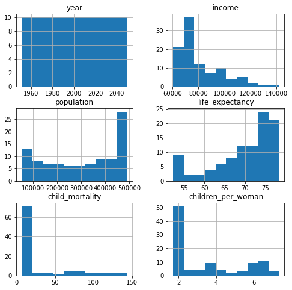

```python
#Distribution of the Brunei dataset
Brunei_subset.hist(figsize= (8,8), grid = True);
```

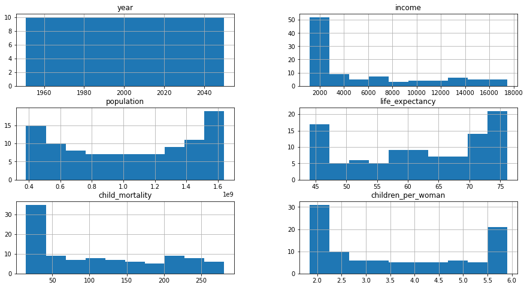

```python
#Distribution of the India dataset
India_subset.hist(figsize = (15, 8));
```

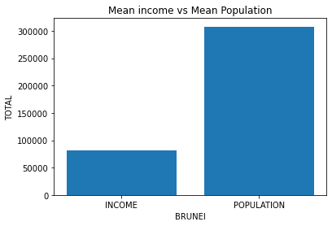

```python
plt.bar(['INCOME', 'POPULATION'], [Brunei_subset.income.mean(), Brunei_subset.population.mean() ])
plt.ylabel('TOTAL')
plt.xlabel('BRUNEI')
plt.title('Mean income vs Mean Population');
```

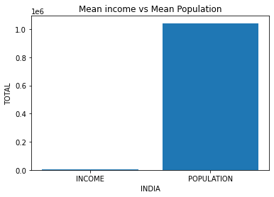

```python
plt.bar(['INCOME', 'POPULATION'], [India_subset.income.mean(), India_subset.population.mean()/1000])
plt.ylabel('TOTAL')
plt.xlabel('INDIA')
plt.title('Mean income vs Mean Population');
```

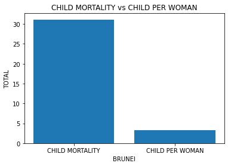

```python
plt.bar(['CHILD MORTALITY', 'CHILD PER WOMAN'], [Brunei_subset.child_mortality.mean(), Brunei_subset.children_per_woman.mean() ])
plt.ylabel('TOTAL')
plt.xlabel('BRUNEI')
plt.title('CHILD MORTALITY vs CHILD PER WOMAN')
plt.show();
```

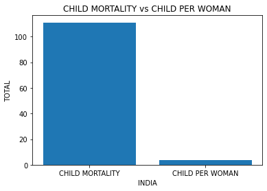

```python
plt.bar(['CHILD MORTALITY', 'CHILD PER WOMAN'], [India_subset.child_mortality.mean(), India_subset.children_per_woman.mean() ])
plt.ylabel('TOTAL')
plt.xlabel('INDIA')
plt.title('CHILD MORTALITY vs CHILD PER WOMAN')
plt.show();
```

##### QUESTION 1

###### Besides the significant population difference between India and Brunei, what other trends in terms of fluctuations are observed over the given time period 1800 to 2050?

```python
# a fuction for line plots
def line(dataframe, x_values, x_label, y_values, y_label, title, color):
    dataframe.plot(x= x_values, y = y_values, color = color, figsize = (12,6), grid = True)
    plt.xlabel(x_label)
    plt.ylabel(y_label)
    plt.title(title, fontsize=12)
    plt.show()
```

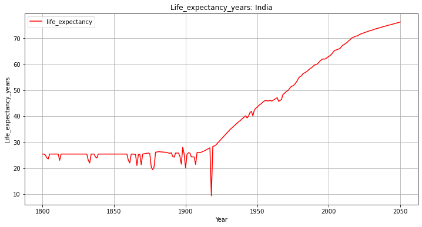

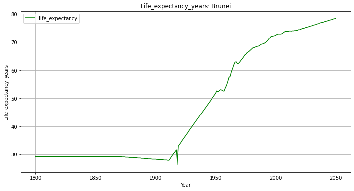

```python
line(df_india,'year', 'Year', 'life_expectancy', 'Life_expectancy_years', 'Life_expectancy_years: India', 'r' )
line(df_brunei,'year', 'Year', 'life_expectancy', 'Life_expectancy_years', 'Life_expectancy_years: Brunei', 'g' )
```

Brunei has always had a higher record of life_expectancy_years compared to India. However they both experienced a rapid sharp increase around the same time in 1900s after having sharply decreased.

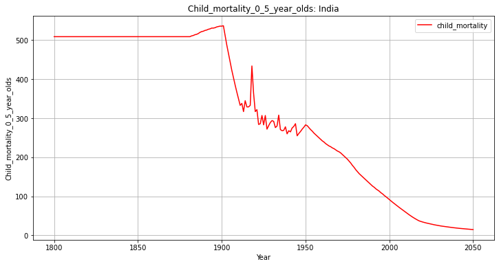

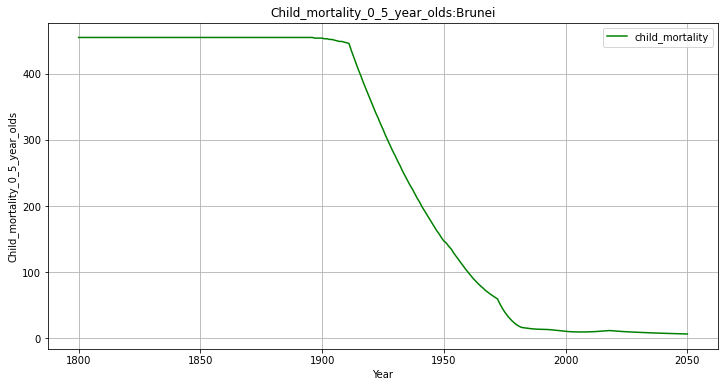

```python
line(df_india,'year', 'Year', 'child_mortality', 'Child_mortality_0_5_year_olds', 'Child_mortality_0_5_year_olds: India', 'r' )
line(df_brunei,'year', 'Year', 'child_mortality', 'Child_mortality_0_5_year_olds', 'Child_mortality_0_5_year_olds:Brunei', 'g' )
```

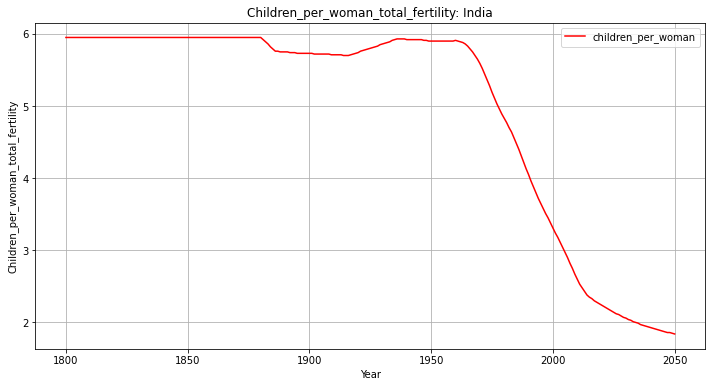

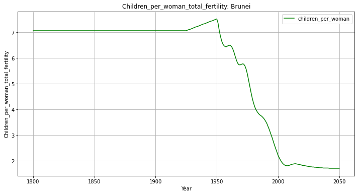

```python
line(df_india,'year', 'Year', 'children_per_woman', 'Children_per_woman_total_fertility', 'Children_per_woman_total_fertility: India', 'r' )
line(df_brunei,'year', 'Year', 'children_per_woman', 'Children_per_woman_total_fertility', 'Children_per_woman_total_fertility: Brunei', 'g' )
```

Both countries experienced a decline from 1950s and onwards however Brunei which once had the highest record, by the year 2000 and after, it was trending to be having the lowest children_per_woman_total_fertility than India.

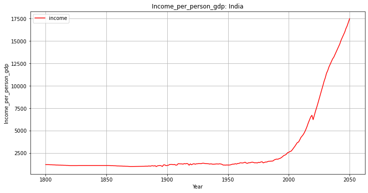

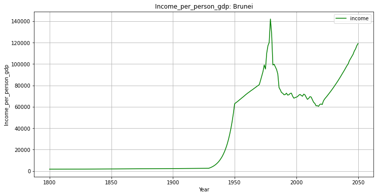

```python
line(df_india,'year', 'Year', 'income', 'Income_per_person_gdp', 'Income_per_person_gdp: India', 'r' )
line(df_brunei,'year', 'Year', 'income', 'Income_per_person_gdp', 'Income_per_person_gdp: Brunei', 'g' )
```

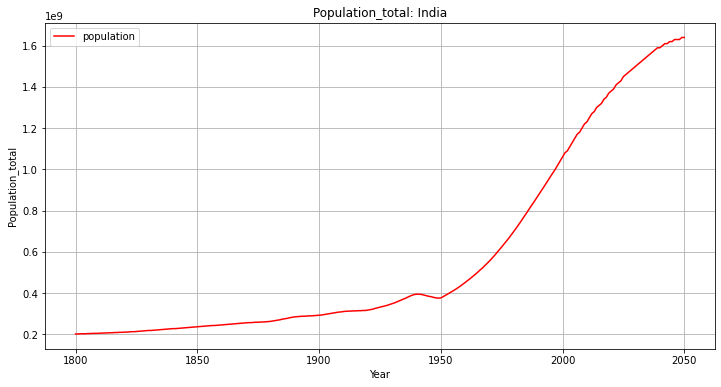

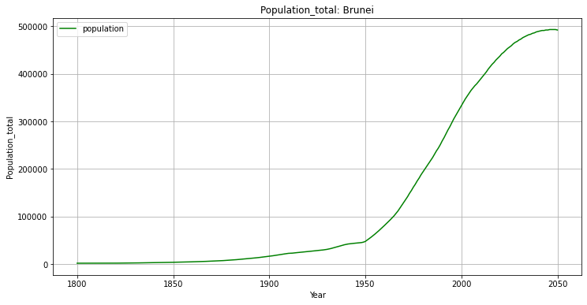

```python
line(df_india,'year', 'Year', 'population', 'Population_total', 'Population_total: India', 'r' )
line(df_brunei,'year', 'Year', 'population', 'Population_total', 'Population_total: Brunei', 'g' );
```

After 1950 India's population has been increasing significantly year after year.